# analyse_cats

The dataset contains 10019 records about YouTube cat-related videos. We use English and Russian search queries to get data in order to cover as much audience as we can. Some Japanese and Korean videos appear also, it's have been discovered by tags or titles. For example English titles with Korean tags. But it was quite a few of them, so no great influence prognosis.

1. Id - technical identifier;
2. Video ID - unique Youtube identifier of video;
3. Title;
4. Video tags;
5. Date of publishing;
6. Duration in seconds;
7. View count of particular video;
8. Likes count;
9. Dislikes count;
10. 'Add to Favourite' count;
11. Comments count;
12. Category - technical data about video category. Have been used in data scrapping;
13. Channel Id - unique Youtube identifier of channel;
14. Channel country;
15. View count of channel;
16. Comments count of channel;
17. Subscribers count of channel;
18. Videos count of channel.

We aim to prognose the View count of a particular video against other data. Clearly understood that technical identifiers like Video ID or Channel ID have no influence on View count, so we need to choose data correctly. A closer look at the dataset shows that 'Add to Favourite' count and Channel comments count are always 0, so we don't need them. Channel category fixed also. It would be nice to have the Channel country in the dataset, but values are very dense and we might have low influence 'cause of the data lack.

Let's do some data preparation: separate data that we need only, normalize numeric values in the range [0, 1], transform date values to timestamp and remove empty values of Video tags.

```python
import pandas
import os
from datetime import datetime
import numpy as np
from math import log


os.chdir("/home/ivla/PycharmProjects/Itea_DS/analyze_data")

data = pandas.read_csv('cat.csv', sep='\t')
data = data[data.columns.difference(['video_id', 'favoriteCount', 'category', 'channel_id', 'channel_comments_count', 'id'])]
data['publishedAt'] = data['publishedAt'].apply(lambda time: datetime.strptime(time, '%Y-%m-%dT%H:%M:%S.%fZ').timestamp())

data['tags'].replace('', np.nan, inplace=True)
data['tags'].replace(' ', np.nan, inplace=True)
data.dropna(subset=['tags'], inplace=True)
data = data.reset_index(drop=True)

data['viewCount'] = data['viewCount'].apply(lambda val: log(int(val) + 1, 10))
print(data.describe())
```

```
       channel_subscribers_count  channel_videos_count  channel_view_count  \
count               9.313000e+03           9313.000000        9.313000e+03
mean                2.818234e+05            995.310641        1.026542e+08
std                 1.218525e+06           6496.502838        4.483937e+08
min                 0.000000e+00              1.000000        2.000000e+00
25%                 5.400000e+01             23.000000        7.774800e+04
50%                 1.308000e+03            101.000000        1.338857e+06
75%                 3.070800e+04            343.000000        2.022275e+07
max                 2.209384e+07         138607.000000        1.425176e+10

        commentCount  dislikeCount     duration     likeCount   publishedAt  \
count    9313.000000   9313.000000  9313.000000  9.313000e+03  9.313000e+03
mean      851.402019    457.877376   781.385053  7.077729e+03  1.401014e+09
std      4277.865879   2850.498834   994.671358  3.193655e+04  1.030711e+08
min         0.000000      0.000000     0.000000  0.000000e+00  1.126288e+09
25%         1.000000      0.000000   121.000000  6.000000e+00  1.324663e+09
50%        11.000000      4.000000   244.000000  6.800000e+01  1.409588e+09
75%       151.000000     55.000000  1124.000000  1.140000e+03  1.492326e+09
max    120440.000000  88114.000000  3592.000000  1.202126e+06  1.540707e+09

         viewCount
count  9313.000000
mean      4.143623
std       1.568930
min       0.000000
25%       3.065206
50%       4.077985
75%       5.282810
max       8.082879
```

```python
numerics = ['int16', 'int32', 'int64', 'float16', 'float32', 'float64']
data_no_normalize = data.select_dtypes(include=numerics).astype('float64')
for column in data_no_normalize:
   max = data_no_normalize[column].max()
   data_no_normalize[column] = data_no_normalize[column] / max

data.update(data_no_normalize)


print(data.describe())
```

```
       channel_subscribers_count  channel_videos_count  channel_view_count  \
count                9313.000000           9313.000000        9.313000e+03
mean                    0.012756              0.007181        7.202914e-03
std                     0.055152              0.046870        3.146235e-02
min                     0.000000              0.000007        1.403336e-10
25%                     0.000002              0.000166        5.455328e-06
50%                     0.000059              0.000729        9.394330e-05
75%                     0.001390              0.002475        1.418966e-03
max                     1.000000              1.000000        1.000000e+00

       commentCount  dislikeCount     duration    likeCount  publishedAt  \
count   9313.000000   9313.000000  9313.000000  9313.000000  9313.000000
mean       0.007069      0.005196     0.217535     0.005888     0.909331
std        0.035519      0.032350     0.276913     0.026567     0.066899
min        0.000000      0.000000     0.000000     0.000000     0.731020
25%        0.000008      0.000000     0.033686     0.000005     0.859776
50%        0.000091      0.000045     0.067929     0.000057     0.914897
75%        0.001254      0.000624     0.312918     0.000948     0.968598
max        1.000000      1.000000     1.000000     1.000000     1.000000

         viewCount
count  9313.000000
mean      0.512642
std       0.194105
min       0.000000
25%       0.379222
50%       0.504521
75%       0.653580
max       1.000000
```

As a result of Video tag trimming we lose about 7% of the dataset - it's an acceptable loss.

Let's check if numeric data in the dataset conform to normal distribution. We'll use the following criteria for each numeric data column:

1. D'Agostino criteria;
2. Jarque-Bera criteria;
3. Kolmogorov-Smirnov criteria;
4. Wilcox criteria.

```python
alpha = 1e-3

from scipy.stats import normaltest
from scipy.stats import jarque_bera
from scipy.stats import kstest
from scipy.stats import wilcoxon

normal_distr_data = data.select_dtypes(include=numerics)

for column in normal_distr_data:
    stat, p = normaltest(normal_distr_data[column])
    print('D\'Agostino hypothesis for {} {}'.format(column, 'approved' if p < alpha else 'rejected'))
    stat, p = jarque_bera(normal_distr_data[column])
    print('Jarque-Bera hypothesis for {} {}'.format(column, 'approved' if p < alpha else 'rejected'))
    stat, p = kstest(normal_distr_data[column], 'norm')
    print('Kolmogorov-Smirnov hypothesis for {} {}'.format(column, 'approved' if p < alpha else 'rejected'))
    stat, p = wilcoxon(normal_distr_data[column])
    print('Wilcoxon hypothesis for {} {}'.format(column, 'approved' if p < alpha else 'rejected'))
```

```
D'Agostino hypothesis for channel_subscribers_count approved
Jarque-Bera hypothesis for channel_subscribers_count approved
Kolmogorov-Smirnov hypothesis for channel_subscribers_count approved
Wilcoxon hypothesis for channel_subscribers_count approved
D'Agostino hypothesis for channel_videos_count approved
Jarque-Bera hypothesis for channel_videos_count approved
Kolmogorov-Smirnov hypothesis for channel_videos_count approved
Wilcoxon hypothesis for channel_videos_count approved
D'Agostino hypothesis for channel_view_count approved
Jarque-Bera hypothesis for channel_view_count approved
Kolmogorov-Smirnov hypothesis for channel_view_count approved
Wilcoxon hypothesis for channel_view_count approved
D'Agostino hypothesis for commentCount approved
Jarque-Bera hypothesis for commentCount approved
Kolmogorov-Smirnov hypothesis for commentCount approved
Wilcoxon hypothesis for commentCount approved
D'Agostino hypothesis for dislikeCount approved
Jarque-Bera hypothesis for dislikeCount approved
Kolmogorov-Smirnov hypothesis for dislikeCount approved
Wilcoxon hypothesis for dislikeCount approved
D'Agostino hypothesis for duration approved
Jarque-Bera hypothesis for duration approved
Kolmogorov-Smirnov hypothesis for duration approved
Wilcoxon hypothesis for duration approved
D'Agostino hypothesis for likeCount approved
Jarque-Bera hypothesis for likeCount approved
Kolmogorov-Smirnov hypothesis for likeCount approved
Wilcoxon hypothesis for likeCount approved
D'Agostino hypothesis for publishedAt approved
Jarque-Bera hypothesis for publishedAt approved
Kolmogorov-Smirnov hypothesis for publishedAt approved
Wilcoxon hypothesis for publishedAt approved
D'Agostino hypothesis for viewCount approved
Jarque-Bera hypothesis for viewCount approved
Kolmogorov-Smirnov hypothesis for viewCount approved
Wilcoxon hypothesis for viewCount approved
```

Now we need to classify text data. Using K-means's intertia parameter determine optimal cluster quantity for Titles and Viedeo tags. Then TF IDF separates Titles and Video tags to determine number of clusters and replaces label with mean View count by cluster.

```python
import nltk
from sklearn.feature_extraction.text import TfidfVectorizer
from sklearn.cluster import KMeans
import matplotlib.pyplot as plt

titles = data['title']

stopwords_list = nltk.corpus.stopwords.words('english') + nltk.corpus.stopwords.words('russian') + ['vs']
vectorizer = TfidfVectorizer(stop_words=stopwords_list)
X = vectorizer.fit_transform(titles)
inertia = []
for k in range(1, 15):
    model = KMeans(n_clusters=k, init='k-means++', max_iter=100, n_init=1, random_state=42)
    model.fit(X)
    inertia.append(model.inertia_)
```

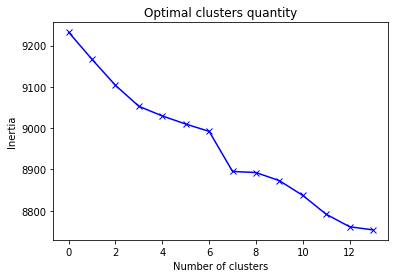

```python
plt.plot(inertia, 'bx-')
plt.xlabel('Number of clusters')
plt.ylabel('Inertia')
plt.title('Optimal clusters quantity')
plt.show()
```

```python
true_k = 6
model = KMeans(n_clusters=true_k, init='k-means++', max_iter=100, n_init=1, random_state=42)
model.fit(X)
title_clusters = []
for title in titles:
    val = model.predict(vectorizer.transform([title]))[0]
    if val:
        title_clusters.append(val)
    else:
        title_clusters.append(0)

title_df = pandas.DataFrame({'title_cluster': title_clusters})

data = data.join(title_df)
```

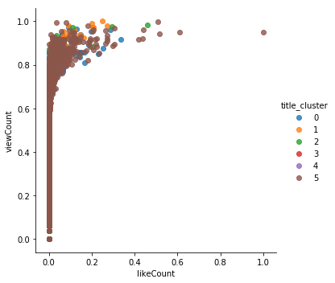

```python
import seaborn as sns
facet = sns.lmplot(data=data, x='likeCount', y='viewCount', hue='title_cluster',
                   fit_reg=False, legend=True, legend_out=True)
```

```python
title_cluster_mean = data[['viewCount']].groupby(data['title_cluster']).mean()
title_cluster_mean_dict = title_cluster_mean.to_dict()['viewCount']
title_cluster_data = data[['title_cluster']].applymap(lambda val: title_cluster_mean_dict[val])

data.update(title_cluster_data)
```

```python
tags = data['tags']

vectorizer = TfidfVectorizer(stop_words=stopwords_list)
X = vectorizer.fit_transform(tags)
inertia = []
for k in range(1, 15):
    model = KMeans(n_clusters=k, init='k-means++', max_iter=100, n_init=1, random_state=42)
    model.fit(X)
    inertia.append(model.inertia_)
```

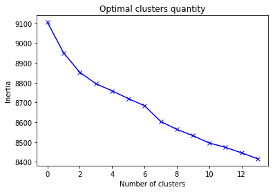

```python
plt.plot(inertia, 'bx-')
plt.xlabel('Number of clusters')
plt.ylabel('Inertia')
plt.title('Optimal clusters quantity')
plt.show()
```

```python
true_k = 6
model = KMeans(n_clusters=true_k, init='k-means++', max_iter=100, n_init=1, random_state=42)
model.fit(X)
tags_clusters = []
for tag in tags:
    val = model.predict(vectorizer.transform([tag]))[0]
    if val:
        tags_clusters.append(val)
    else:
        tags_clusters.append(0)
tags_df = pandas.DataFrame({'tags_cluster': tags_clusters})
data = data.join(tags_df)
```

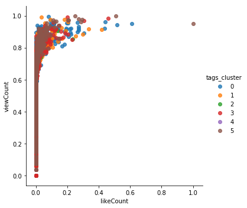

```python
facet = sns.lmplot(data=data, x='likeCount', y='viewCount', hue='tags_cluster',
                   fit_reg=False, legend=True, legend_out=True)
```

```python
tag_cluster_mean = data[['viewCount']].groupby(data['tags_cluster']).mean()
tag_cluster_mean_dict = tag_cluster_mean.to_dict()['viewCount']
tag_cluster_data = data[['tags_cluster']].applymap(lambda val: tag_cluster_mean_dict[val])
data.update(tag_cluster_data)

print(data.describe())
```

```
       channel_subscribers_count  channel_videos_count  channel_view_count  \
count                9313.000000           9313.000000        9.313000e+03
mean                    0.012756              0.007181        7.202914e-03
std                     0.055152              0.046870        3.146235e-02
min                     0.000000              0.000007        1.403336e-10
25%                     0.000002              0.000166        5.455328e-06
50%                     0.000059              0.000729        9.394330e-05
75%                     0.001390              0.002475        1.418966e-03
max                     1.000000              1.000000        1.000000e+00

       commentCount  dislikeCount     duration    likeCount  publishedAt  \
count   9313.000000   9313.000000  9313.000000  9313.000000  9313.000000
mean       0.007069      0.005196     0.217535     0.005888     0.909331
std        0.035519      0.032350     0.276913     0.026567     0.066899
min        0.000000      0.000000     0.000000     0.000000     0.731020
25%        0.000008      0.000000     0.033686     0.000005     0.859776
50%        0.000091      0.000045     0.067929     0.000057     0.914897
75%        0.001254      0.000624     0.312918     0.000948     0.968598
max        1.000000      1.000000     1.000000     1.000000     1.000000

         viewCount  title_cluster  tags_cluster
count  9313.000000    9313.000000   9313.000000
mean      0.512642       0.512642      0.512642
std       0.194105       0.035007      0.040867
min       0.000000       0.358104      0.444078
25%       0.379222       0.494840      0.490547
50%       0.504521       0.494840      0.490547
75%       0.653580       0.528451      0.557416
max       1.000000       0.609804      0.597082
```

So data preparation is over and we're ready to basic analysis.

Use Spearman's correlation matrix to looks what we have.

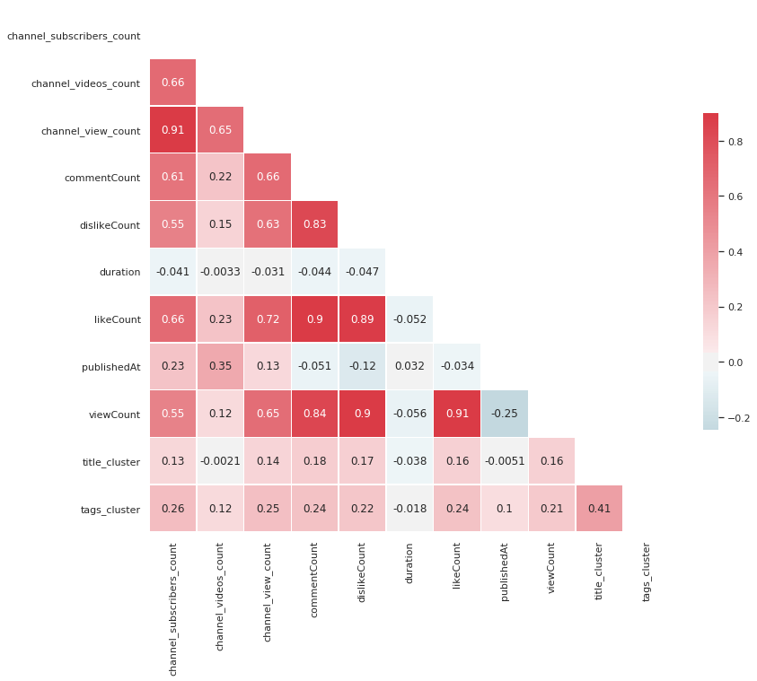

```python
import numpy as np
import matplotlib.pyplot as plt

data_corr = data[data.columns.difference(['id', 'tags', 'title', 'channel_country'])]

corr = data.corr(method='spearman', min_periods=9300)

sns.set(style="white")
mask = np.zeros_like(corr, dtype=np.bool)
mask[np.triu_indices_from(mask)] = True
f, ax = plt.subplots(figsize=(13, 13))
cmap = sns.diverging_palette(220, 10, as_cmap=True)
sns.heatmap(corr, mask=mask, cmap=cmap, annot=True, vmax=.9, center=0,
            square=True, linewidths=.5, cbar_kws={"shrink": .5})
```

Video duration has no correlation to any parameter at all, so it might be excluded from the model. High correlation to View count has the following parameters:

1. Likes count;
2. Dislikes count;
3. Comments count;
4. Channel subscribers count.

But Dislikes count and Comments count correlate to Likes count also. Take as base parameter Likes count calculate Dislikes count and Comments count using Linear regression. Then use only the residual values in the model.

Do the same with Channel subscribers count and Channel view count.

```python
from sklearn.linear_model import LinearRegression

lr = LinearRegression(normalize=True)

x = data['likeCount'].values.reshape(len(data['likeCount']), 1)
y = data['dislikeCount'].values.reshape(len(data['dislikeCount']), 1)
lr.fit(x, y)
print('Coefficient', round(lr.coef_[0][0], 20))
```

```
Coefficient 0.7159880884224487
```

```python
likes_dislikes_pred = lr.predict(x)

from sklearn.metrics import mean_squared_error, r2_score
from scipy import stats

print("Mean squared error: %.2f" % mean_squared_error(y, likes_dislikes_pred))

print('Variance score: %.2f' % r2_score(y, likes_dislikes_pred))

print('Before: ', round(stats.pearsonr(x, y)[0][0],5))
print('After: ', round(stats.pearsonr(x, y-likes_dislikes_pred)[0][0],5))
```

```
Mean squared error: 0.00
Variance score: 0.35
Before:  0.58799
After:  0.0
```

```python
from pandas import DataFrame
dislikes_df = DataFrame(y - likes_dislikes_pred, columns=['dislikeCount'])
data.update(dislikes_df)
```

```python
y = data['commentCount'].values.reshape(len(data['commentCount']), 1)
lr.fit(x, y)
print('Coefficient', round(lr.coef_[0][0], 20))
```

```
Coefficient 1.1574641728614443
```

```python
likes_comments_pred = lr.predict(x)

print("Mean squared error: %.2f" % mean_squared_error(y, likes_comments_pred))

print('Variance score: %.2f' % r2_score(y, likes_comments_pred))

from scipy import stats

print('Before: ', round(stats.pearsonr(x, y)[0][0],5))
print('After: ', round(stats.pearsonr(x, y-likes_comments_pred)[0][0],5))
```

```
Mean squared error: 0.00
Variance score: 0.75
Before:  0.86574
After:  0.0
```

```python
comments_df = DataFrame(y - likes_comments_pred, columns=['commentCount'])
data.update(comments_df)
```

```python
x = data['channel_view_count'].values.reshape(len(data['channel_view_count']), 1)
y = data['channel_subscribers_count'].values.reshape(len(data['channel_subscribers_count']), 1)
lr.fit(x, y)
print('Coefficient', round(lr.coef_[0][0], 20))
```

```
Coefficient 1.4200171711985827
```

```python
channel_views_pred = lr.predict(x)

print("Mean squared error: %.2f" % mean_squared_error(y, channel_views_pred))

print('Variance score: %.2f' % r2_score(y, channel_views_pred))
print('Before: ', round(stats.pearsonr(x, y)[0][0],5))
print('After: ', round(stats.pearsonr(x, y-channel_views_pred)[0][0],5))
```

```
Mean squared error: 0.00
Variance score: 0.66
Before:  0.81007
After:  0.0
```

```python
channel_views_df = DataFrame(y - channel_views_pred, columns=['channel_view_count'])
data.update(channel_views_df)
```

```python
x = data['likeCount'].values.reshape(len(data['likeCount']), 1)
y = data['channel_subscribers_count'].values.reshape(len(data['channel_subscribers_count']), 1)
lr.fit(x, y)
print('Coefficient', round(lr.coef_[0][0], 20))
```

```
Coefficient 0.7543299975002606
```

```python
channel_subscribers_pred = lr.predict(x)

print("Mean squared error: %.2f" % mean_squared_error(y, channel_subscribers_pred))

print('Variance score: %.2f' % r2_score(y, channel_subscribers_pred))
print('Before: ', round(stats.pearsonr(x, y)[0][0],5))
print('After: ', round(stats.pearsonr(x, y-channel_subscribers_pred)[0][0],5))
```

```
Mean squared error: 0.00
Variance score: 0.13
Before:  0.36336
After:  -0.0
```

```python
channel_subscribers_df = DataFrame(y - channel_subscribers_pred, columns=['channel_subscribers_count'])
data.update(channel_subscribers_df)
```

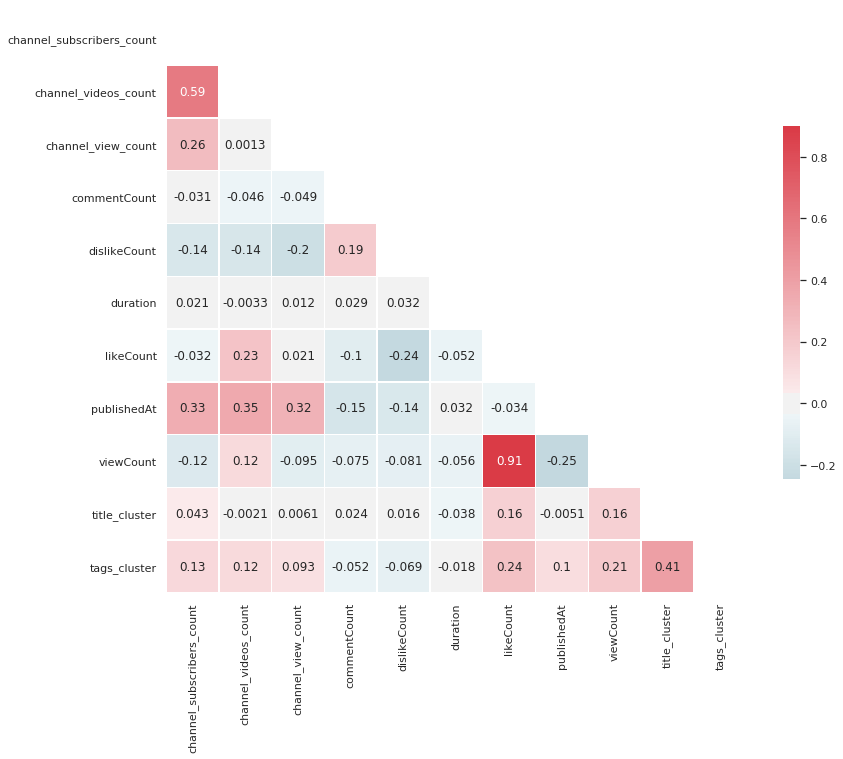

```python
import seaborn as sns
import numpy as np
import matplotlib.pyplot as plt

data_corr = data[data.columns.difference(['id', 'tags', 'title', 'channel_country'])]

corr = data.corr(method='spearman', min_periods=9300)

sns.set(style="white")
mask = np.zeros_like(corr, dtype=np.bool)
mask[np.triu_indices_from(mask)] = True
f, ax = plt.subplots(figsize=(13, 13))
cmap = sns.diverging_palette(220, 10, as_cmap=True)
sns.heatmap(corr, mask=mask, cmap=cmap, annot=True, vmax=.9, center=0,
            square=True, linewidths=.5, cbar_kws={"shrink": .5})
```

As far as we get rid of correlation we're ready to build the first model for prediction. Build a few models to compare its results. As criteria take RMSE.

For the first step, we'll build naive NN: two layers contain one neuron each. Just for fun :) Model's hyperparameters obtained experimentally.

```python
from sklearn.model_selection import train_test_split

X_train, X_test, y_train, y_test = train_test_split(data[['likeCount', 'dislikeCount', 'commentCount', 'channel_view_count',
                                                         'channel_videos_count', 'channel_subscribers_count']].values,
                                                    data[['viewCount']].values,
                                                    test_size=0.2, random_state=1)

X_train = X_train.reshape((X_train.shape[0], 1, X_train.shape[1]))
y_train = y_train.reshape((y_train.shape[0], 1, y_train.shape[1]))
X_test = X_test.reshape((X_test.shape[0], 1, X_test.shape[1]))
y_test = y_test.reshape((y_test.shape[0], 1, y_test.shape[1]))
```

```python
from keras.models import Sequential
from keras.layers import Dense
from numpy.random import seed
import keras.losses as loss

seed(42)

def rmse(y_test, y_pred):
    return loss.mean_squared_error(y_test, y_pred) ** 0.5

batch_size = 100
epoch = 20

n_model = Sequential()
n_model.add(Dense(1, activation='relu'))
n_model.add(Dense(1, activation='tanh'))
n_model.compile(loss='mse', optimizer='adam', metrics=[rmse])
history = n_model.fit(X_train, y_train, batch_size=batch_size, epochs=epoch, validation_data=(X_test, y_test),
                      verbose=0)
score = n_model.evaluate(X_test, y_test, batch_size=batch_size)
print('{:4e}'.format(score[1]))
```

```
1.470301e-01
```

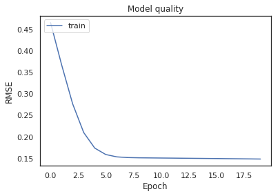

```python
plt.plot(history.history['rmse'])
plt.title('Model quality')
plt.ylabel('RMSE')
plt.xlabel('Epoch')
plt.legend(['train'], loc='upper left')

plt.show()
```

```python
X_train, X_test, y_train, y_test = train_test_split(data[['likeCount', 'dislikeCount', 'commentCount', 'channel_view_count',
                                                         'channel_videos_count', 'channel_subscribers_count']].values,
                                                    data[['viewCount']].values,
                                                    test_size=0.2, random_state=1)
```

```python
def RMSE(y_test, y_pred):
    return (sum((y_test - y_pred) ** 2) / len(y_test)) ** 0.5

from sklearn.linear_model import LinearRegression
from sklearn.preprocessing import PolynomialFeatures

for i in range(1, 5):
    poly_features = PolynomialFeatures(degree=i, include_bias=False)
    X_poly = poly_features.fit_transform(X_train)
    lin_reg = LinearRegression()
    lin_reg.fit(X_poly, y_train)
    print(i, '{:4e}'.format(RMSE(y_test, lin_reg.predict(poly_features.fit_transform(X_test)))[0]))
```

```
1 1.742633e-01
2 1.754711e-01
3 3.007704e+00
4 4.034230e+01
```

The best fit have been obtained using Ploynomial regression with 1st degree polynom e.g. linear regression.

Then use Bagging and Random Forest and then compare all models.

```python
from sklearn.tree import DecisionTreeRegressor
from sklearn.ensemble import BaggingRegressor

tree = DecisionTreeRegressor(max_depth=15, max_features=0.8, max_leaf_nodes=50)
bag = BaggingRegressor(tree, n_estimators=100, max_samples=0.8, random_state=42, max_features=0.8)
bag.fit(X_train, y_train)

print('{:4e}'.format(RMSE(y_test, bag.predict(X_test))[0]))
```

```
1.960217e-01
```

```python
from sklearn.ensemble import RandomForestRegressor

random_forest = RandomForestRegressor(n_estimators=100, max_depth=15, random_state=42, max_features=0.8, max_leaf_nodes=50)
random_forest.fit(X_train, y_train)

print('{:4e}'.format(RMSE(y_test, random_forest.predict(X_test))[0]))
```

```
1.970156e-01
```

As we may see the naive NN has minimal RMSE value and suits best for prediction.

Take as a base NN and try to tune its hyperparameters automatically.

```python
from talos import Scan
from keras.activations import *
from keras.optimizers import Adam
from keras.models import Sequential
from keras.layers import Dense

from keras.layers import Dropout

def opt_model_f(X_train, y_train, X_test, y_test, params):
    opt_model = Sequential()
    opt_model.add(Dense(params['first_layer'], activation=params['first_layer_activation']))
    opt_model.add(Dropout(params['dropout']))
    opt_model.add(Dense(1, activation=params['last_layer_activation']))
    opt_model.compile(loss='mse', optimizer=Adam(lr=params['lr']), metrics=[rmse])
    history = opt_model.fit(X_train, y_train, validation_data=(X_test, y_test), batch_size=params['batch_size'],
                            epochs=params['epoch'], verbose=0)
    return history, opt_model

p = {
    'first_layer': [1, 2, 10, 50],
    'first_layer_activation': [elu, relu, selu],
    'last_layer_activation': [tanh, sigmoid],
    'batch_size': [20, 50, 100, 200],
    'epoch': [20, 50, 100, 200],
    'dropout': [0, 0.1, 0.3],
    'lr': [0.2, 0.1, 0.05]
}

X_train, X_test, y_train, y_test = train_test_split(
    data[['likeCount', 'dislikeCount', 'commentCount', 'channel_view_count',
          'channel_videos_count', 'channel_subscribers_count']].values,
    data[['viewCount']].values,
    test_size=0.2, random_state=1)

X_train = X_train.reshape((X_train.shape[0], 1, X_train.shape[1]))
y_train = y_train.reshape((y_train.shape[0], 1, y_train.shape[1]))
X_test = X_test.reshape((X_test.shape[0], 1, X_test.shape[1]))
y_test = y_test.reshape((y_test.shape[0], 1, y_test.shape[1]))

# !WARNING: do not uncomment and run this piece of code until you'll want to spend few hours (or dozen hours) to observe progress bar
# t = Scan(x=X_train, y=y_train, x_val=X_test, y_val=y_test, model=opt_model_f, params=p, reduction_metric=rmse,
#         dataset_name='NN_tuning', experiment_no='1')
```

```
0.06049237869403981
```

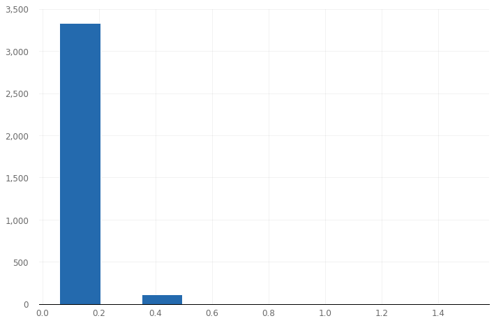

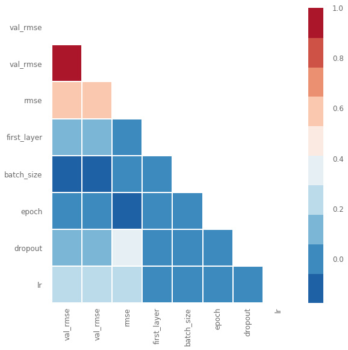

```python
import talos as ta
r = ta.Reporting('NN_tuning_1.csv')
print(r.low(metric='val_rmse'))
r.plot_hist(metric='val_rmse')
r.plot_corr(metric='val_rmse', color_grades=10)
```

Fond of correlation matrix - it shows that RMSE value depends mostly on First layer neurons quantity and Learning rate. It could be helpful in case if we aim to optimize the model again.

The following hyperparameters have been obtained after tuning:

1. First layer neurons quantity - 50;
2. First layer activation function - ReLU;
3. Second layer activation function - Sigmoid;
4. Batch size - 50;
5. Number of epochs - 100;
6. Dropout - 0.0;
7. Learning rate - 0.05.

I have a doubt about whether it helps to obtain better prediction but still, we'll try to rebuild the model.

```python
from keras.optimizers import Adam
seed(42)

X_train, X_test, y_train, y_test = train_test_split(
    data[['likeCount', 'dislikeCount', 'commentCount', 'channel_view_count',
          'channel_videos_count', 'channel_subscribers_count']].values,
    data[['viewCount']].values,
    test_size=0.2, random_state=1)

X_train = X_train.reshape((X_train.shape[0], 1, X_train.shape[1]))
y_train = y_train.reshape((y_train.shape[0], 1, y_train.shape[1]))
X_test = X_test.reshape((X_test.shape[0], 1, X_test.shape[1]))
y_test = y_test.reshape((y_test.shape[0], 1, y_test.shape[1]))

new_model = Sequential()
new_model.add(Dense(50, activation='relu'))
new_model.add(Dense(1, activation='sigmoid'))
new_model.compile(loss='mse', optimizer=Adam(lr=0.05), metrics=[rmse])
history = new_model.fit(X_train, y_train, validation_data=(X_test, y_test), batch_size=50, epochs=100, verbose=0)
score = new_model.evaluate(X_test, y_test, batch_size=50)
print('{:4e}'.format(score[1]))
```

```
9.248405e-02
```

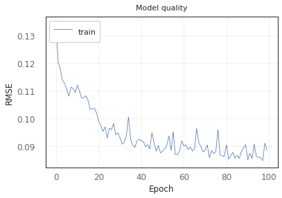

```python
plt.plot(history.history['rmse'])
plt.title('Model quality')
plt.ylabel('RMSE')
plt.xlabel('Epoch')
plt.legend(['train'], loc='upper left')

plt.show()
```

Well, we have some profit from tuning - RMSE value decreased. Could it be any better? Run for 'round two' of tuning:

```python
p1 = {
    'first_layer': [43, 44, 45, 46, 47, 48, 49, 50, 51, 52, 53, 54],
    'first_layer_activation': [relu],
    'last_layer_activation': [sigmoid],
    'batch_size': [80, 90, 100, 110],
    'epoch': [80, 90, 100, 110],
    'dropout': [0],
    'lr': [0.03, 0.04, 0.05, 0.06]
}

# !WARNING: do not uncomment and run this piece of code until you'll want to spend few hours (or dozen hours) to observe progress bar
# t = Scan(x=X_train, y=y_train, x_val=X_test, y_val=y_test, model=opt_model_f, params=p1, reduction_metric=rmse,
#          dataset_name='NN_tuning', experiment_no='2')
```

```
0.06025138126623227
```

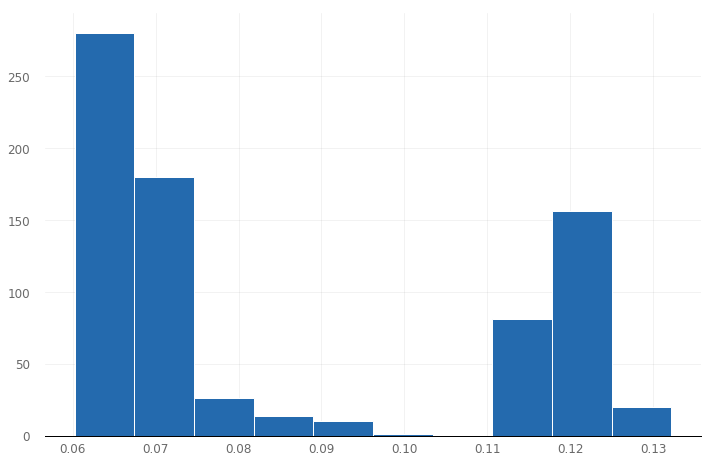

```python
import talos as ta
r = ta.Reporting('NN_tuning_2.csv')
print(r.low(metric='val_rmse'))
r.plot_hist(metric='val_rmse')
```

The following hyperparameters have been obtained after tuning:

1. First layer neurons quantity - 44;
2. Batch size - 90;
3. Number of epochs - 110;
4. Learning rate - 0.04.

Rebuild the model again and evaluate RMSE value.

```python
seed(42)

X_train, X_test, y_train, y_test = train_test_split(
    data[['likeCount', 'dislikeCount', 'commentCount', 'channel_view_count',
          'channel_videos_count', 'channel_subscribers_count']].values,
    data[['viewCount']].values,
    test_size=0.2, random_state=1)

X_train = X_train.reshape((X_train.shape[0], 1, X_train.shape[1]))
y_train = y_train.reshape((y_train.shape[0], 1, y_train.shape[1]))
X_test = X_test.reshape((X_test.shape[0], 1, X_test.shape[1]))
y_test = y_test.reshape((y_test.shape[0], 1, y_test.shape[1]))

new_model2 = Sequential()
new_model2.add(Dense(44, activation='relu'))
new_model2.add(Dense(1, activation='sigmoid'))
new_model2.compile(loss='mse', optimizer=Adam(lr=0.04), metrics=[rmse])
history = new_model2.fit(X_train, y_train, validation_data=(X_test, y_test), batch_size=90, epochs=110, verbose=0)
score = new_model2.evaluate(X_test, y_test, batch_size=110)
print('{:4e}'.format(score[1]))
```

```
7.217760e-02
```

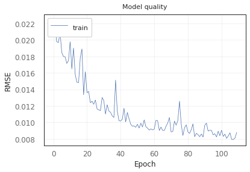

```python
plt.plot(history.history['val_loss'])
plt.title('Model quality')
plt.ylabel('RMSE')
plt.xlabel('Epoch')
plt.legend(['train'], loc='upper left')

plt.show()
```

Use an optimized model for View count prediction. For example, we have a YouTube channel with cat videos. We post new ones and ask subscribers about 10000 likes :) For example, take:

1. Likes count - 8675 / 1202126 = 0.00721638;
2. Diskiles count - 547 / 88114 = 0.00620787;
3. Comments count - 165 / 120440 = 0.00137;
4. Channel view count - 154862 / 14251756132 = 0.00001087;
5. Channel videos count - 57 / 138607 = 0.00041123;
6. Channel subscribers count - 12547 / 22093838 = 0.0005679.

```python
import numpy as np
test_data = np.array([[0.00721638, 0.00620787, 0.00137, 0.00001087, 0.00041123, 0.0005679]])
test_data = test_data.reshape(test_data.shape[0], 1, test_data.shape[1])
predicted_view_count = new_model2.predict(test_data)
print(predicted_view_count)
```

```
[[[0.7600049]]]
```

Using quite complex math transformation we may obtain real View count value :)

```python
view_count_value = 10 ** (0.7600049 * 8.082879)
print(view_count_value)
```

```
1390041.1149588546
```

We obtain the predicted value of View count equal to 1390000 approximately.

In 2013 YouTube's average Cost per thousand (CPE) was about $7.6. Assume that average CPE decreased to $5.0 now. So in the end we could earn up to $6950 on the pussy cats video.

The results make me feel like I had to quit machine learning and start my own YouTube channel :)